# TP 5

Adrien Hardy

```r
library(tseries)
library(forecast)
library(caschrono)
library(fGarch)
# set.seed(123) # je fixe les réalisations aléatoires
```

# EXERCICE I

```r
?garchSim
```

## Modèle ARCH(1)

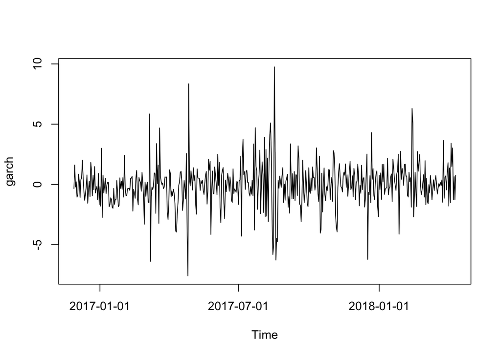

```r
spec = garchSpec(model = list(omega = 1, alpha = c(0.8), beta = 0))
X <- garchSim(spec, n = 500)
plot(X)
```

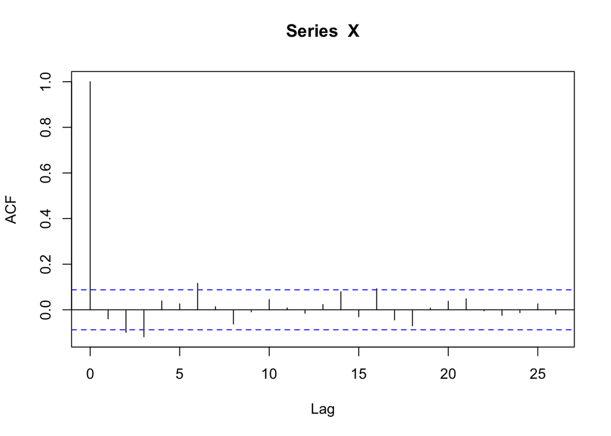

```r
acf(X)
```

```r
Box.test.2(X,1:20)
```

```
##       Retard    p-value
##  [1,]      1 0.37479047
##  [2,]      2 0.05804548
##  [3,]      3 0.00527414
##  [4,]      4 0.00907868
##  [5,]      5 0.01663220
##  [6,]      6 0.00218158
##  [7,]      7 0.00428588
##  [8,]      8 0.00389009
##  [9,]      9 0.00701217
## [10,]     10 0.00851219
## [11,]     11 0.01401100
## [12,]     12 0.02148134
## [13,]     13 0.03023286
## [14,]     14 0.01787048
## [15,]     15 0.02352157
## [16,]     16 0.01000353
## [17,]     17 0.01132053
## [18,]     18 0.00830769
## [19,]     19 0.01224506
## [20,]     20 0.01465810
```

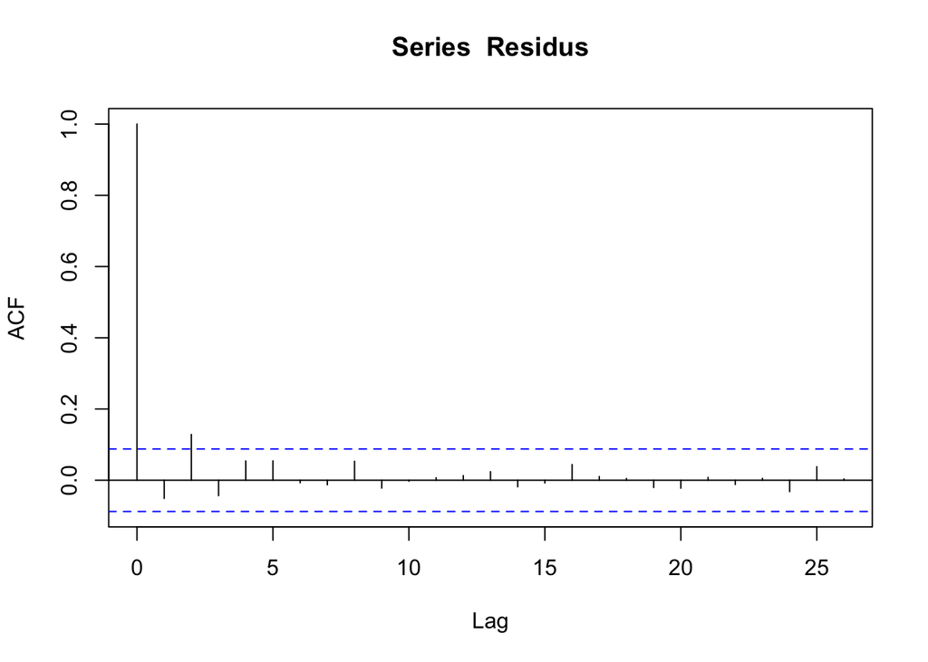

```r
Residus <- residuals(arima(X^2, order=c(1,0,0)))
acf(Residus)
```

```r
Box.test.2(Residus,1:20)
```

```
##       Retard    p-value
##  [1,]      1 0.25364361
##  [2,]      2 0.00838127
##  [3,]      3 0.01475421
##  [4,]      4 0.01760368
##  [5,]      5 0.01954620
##  [6,]      6 0.03614874
##  [7,]      7 0.05977032
##  [8,]      8 0.05980713
##  [9,]      9 0.08535465
## [10,]     10 0.12450461
## [11,]     11 0.17193081
## [12,]     12 0.22437568
## [13,]     13 0.27086284
## [14,]     14 0.32706449
## [15,]     15 0.39487266
## [16,]     16 0.39987510
## [17,]     17 0.46561077
## [18,]     18 0.53364359
## [19,]     19 0.58606819
## [20,]     20 0.63303869
```

## Modèle ARCH(3)

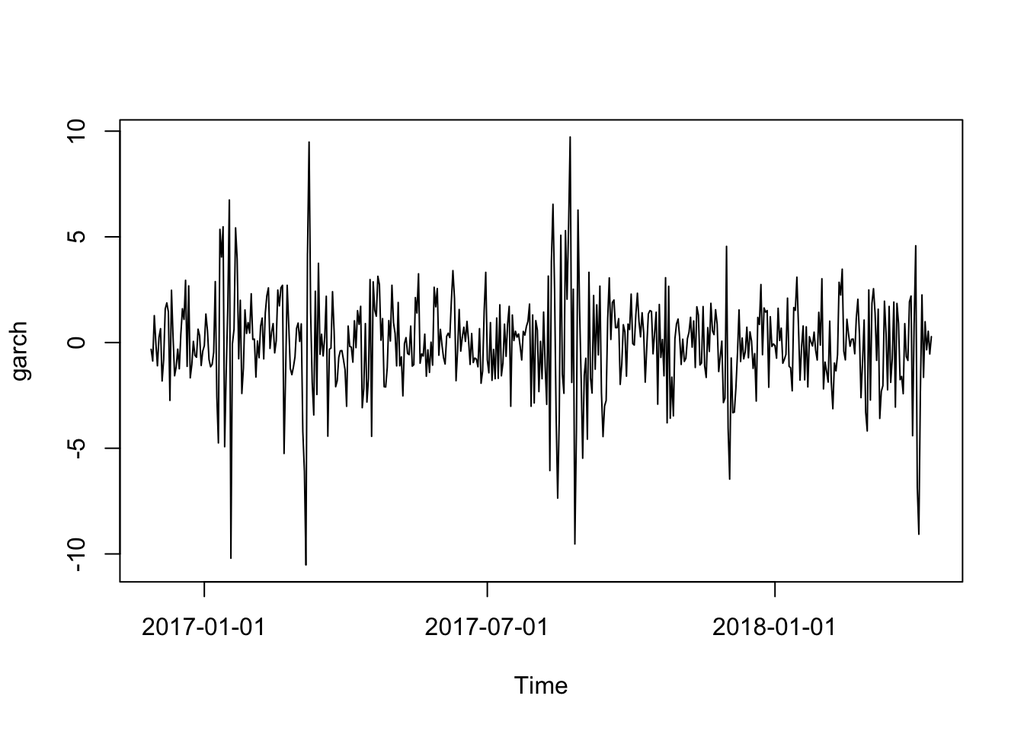

```r
spec = garchSpec(model = list(omega = 1, alpha = c(0.5,0.1,0.3), beta = 0))
X <- garchSim(spec, n = 500)
plot(X)
```

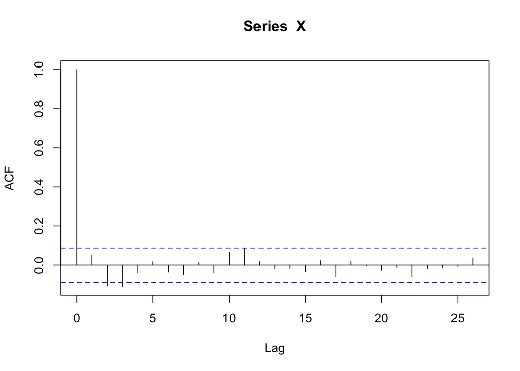

```r
acf(X)
```

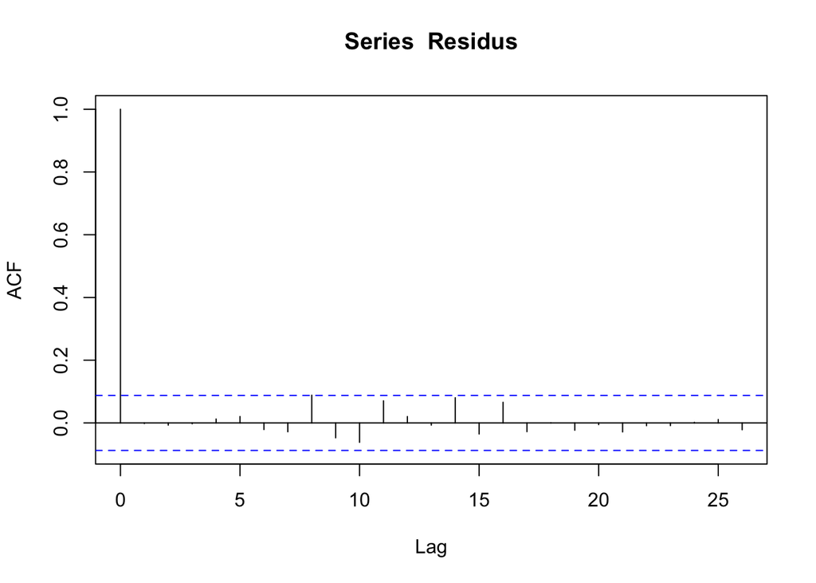

```r
Residus <- residuals(arima(X^2, order=c(3,0,0)))
acf(Residus)
```

```r
Box.test.2(Residus,1:20)
```

```
##       Retard   p-value
##  [1,]      1 0.9644953
##  [2,]      2 0.9870417
##  [3,]      3 0.9986589
##  [4,]      4 0.9986184
##  [5,]      5 0.9973485
##  [6,]      6 0.9973354
##  [7,]      7 0.9957780
##  [8,]      8 0.7728837
##  [9,]      9 0.7418514
## [10,]     10 0.6389294
## [11,]     11 0.4965860
## [12,]     12 0.5647410
## [13,]     13 0.6434901
## [14,]     14 0.4620679
## [15,]     15 0.4909645
## [16,]     16 0.4100683
## [17,]     17 0.4532260
## [18,]     18 0.5219448
## [19,]     19 0.5702670
## [20,]     20 0.6331217
```

## Modèle GARCH(1,1)

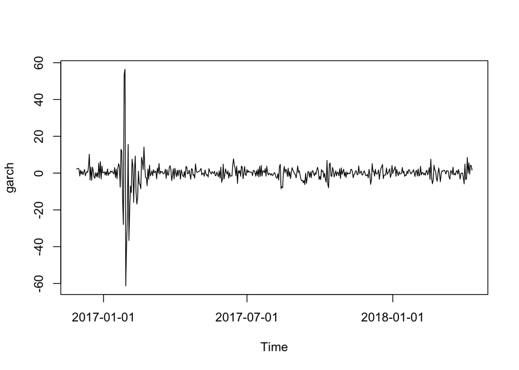

```r
spec = garchSpec(model = list(omega = 1, alpha = c(0.5), beta = c(0.4)))
X <- garchSim(spec, n = 500)
plot(X)
```

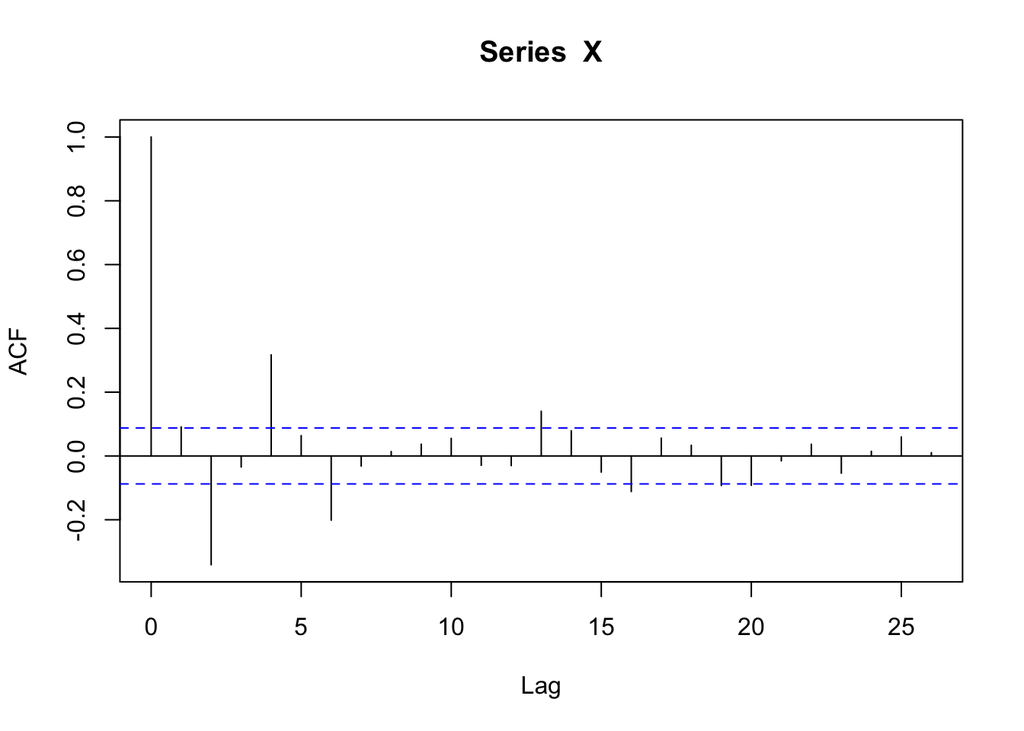

```r
acf(X)
```

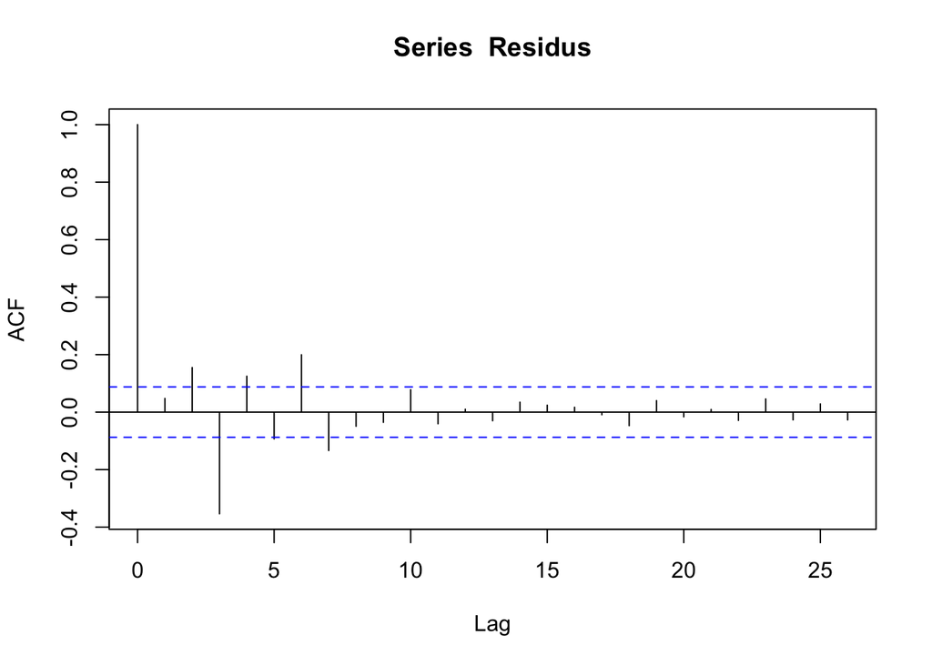

```r
Residus <- residuals(arima(X^2, order=c(1,0,1)))
acf(Residus)
```

```r
Box.test.2(Residus,1:20)
```

```
##       Retard    p-value
##  [1,]      1 0.28732449
##  [2,]      2 0.00140039
##  [3,]      3 0.00000000
##  [4,]      4 0.00000000
##  [5,]      5 0.00000000
##  [6,]      6 0.00000000
##  [7,]      7 0.00000000
##  [8,]      8 0.00000000
##  [9,]      9 0.00000000
## [10,]     10 0.00000000
## [11,]     11 0.00000000
## [12,]     12 0.00000000
## [13,]     13 0.00000000
## [14,]     14 0.00000000
## [15,]     15 0.00000000
## [16,]     16 0.00000000
## [17,]     17 0.00000000
## [18,]     18 0.00000000
## [19,]     19 0.00000000
## [20,]     20 0.00000000
```

## Modèle GARCH(2,3)

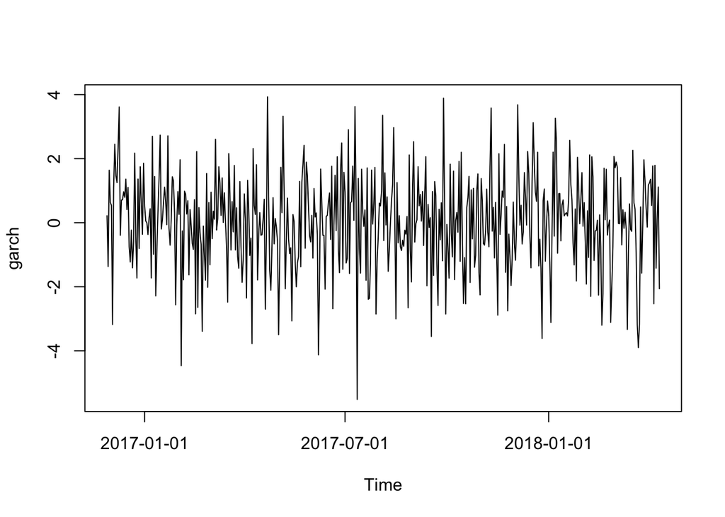

```r
spec = garchSpec(model = list(omega = 1, alpha = c(0.06,0.1), beta = c(0.2,0.15,0.1)))
X <- garchSim(spec, n = 500)
plot(X)
```

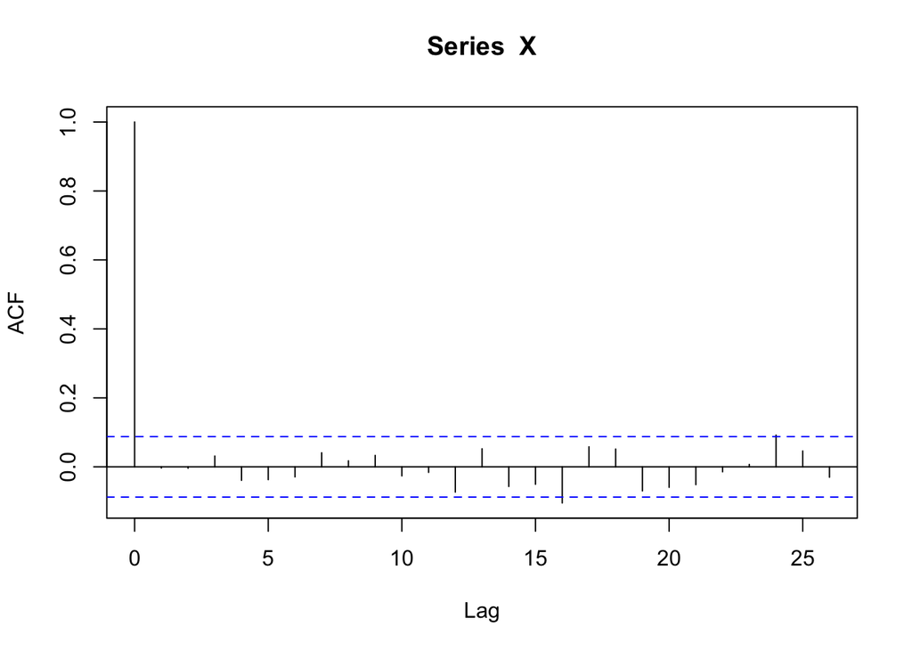

```r
acf(X)
```

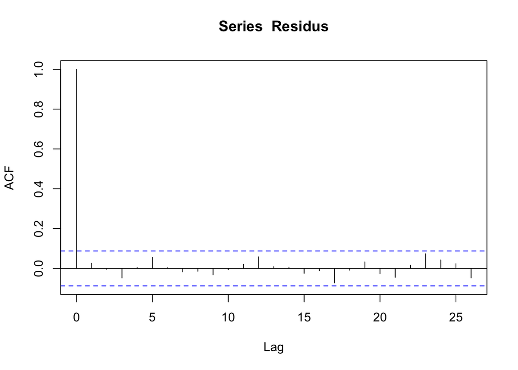

```r
Residus <- residuals(arima(X^2, order=c(3,0,3)))
acf(Residus)
```

```r
Box.test.2(Residus,1:20)
```

```
##       Retard   p-value
##  [1,]      1 0.5592017
##  [2,]      2 0.8378062
##  [3,]      3 0.6804462
##  [4,]      4 0.8240519
##  [5,]      5 0.6955286
##  [6,]      6 0.8044649
##  [7,]      7 0.8668329
##  [8,]      8 0.9143899
##  [9,]      9 0.9237524
## [10,]     10 0.9550390
## [11,]     11 0.9689032
## [12,]     12 0.9285905
## [13,]     13 0.9537861
## [14,]     14 0.9712432
## [15,]     15 0.9778869
## [16,]     16 0.9861581
## [17,]     17 0.9462377
## [18,]     18 0.9632284
## [19,]     19 0.9664228
## [20,]     20 0.9727337
```

# EXERCICE 2

On récupère le jeu de données INTC (en specifiant d’abord le répertoire où R doit chercher) :

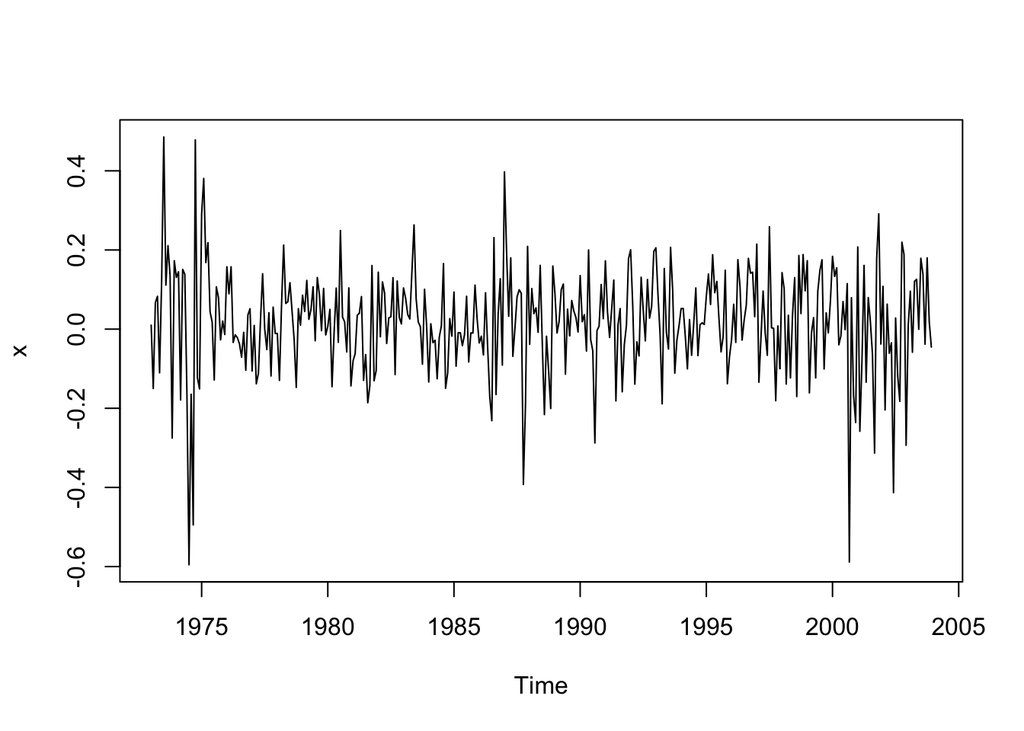

```r
# setwd("/Users/adrien/R/Data")
Dat0 <- read.table("/Users/adrien/R/Data/INTC", header=T)
INTC <- ts(data = Dat0, start=c(1973,1),end=c(2003,12), frequency=12)
plot(INTC)
```

On étudie la série INTC :

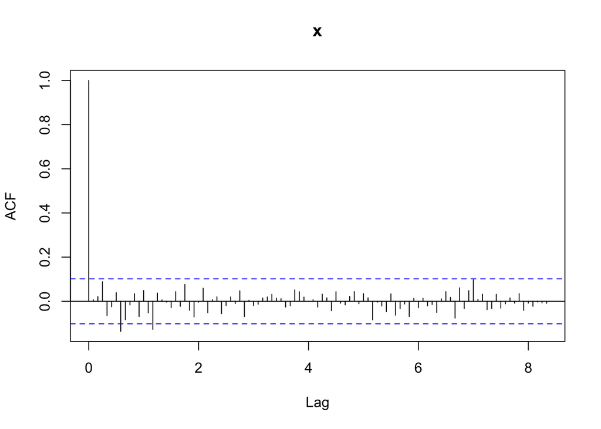

```r
acf(INTC,lag=100)
```

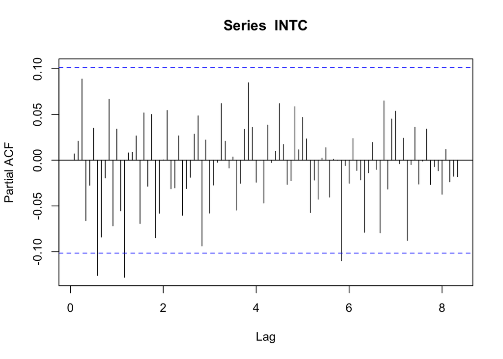

```r
pacf(INTC,lag=100)
```

```r
Box.test.2(INTC,1:50)
```

```
##       Retard    p-value
##  [1,]      1 0.89386607
##  [2,]      2 0.91427190
##  [3,]      3 0.37222884
##  [4,]      4 0.32435131
##  [5,]      5 0.43077263
##  [6,]      6 0.48746844
##  [7,]      7 0.08921509
##  [8,]      8 0.06034335
##  [9,]      9 0.08975699
## [10,]     10 0.11540033
## [11,]     11 0.10113237
## [12,]     12 0.11191248
## [13,]     13 0.11873731
## [14,]     14 0.03322213
```

[output cut: 36 more lines]

D’après le test de Box-Pierce, l’hypothèse d’un bruit blanc ne peut pas être rejetée.

On étudie maintenant cette série élevée au carré pour débusquer un effet ARCH :

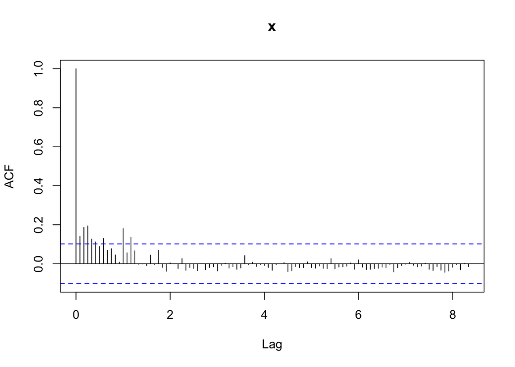

```r
acf(INTC^2,lag=100)
```

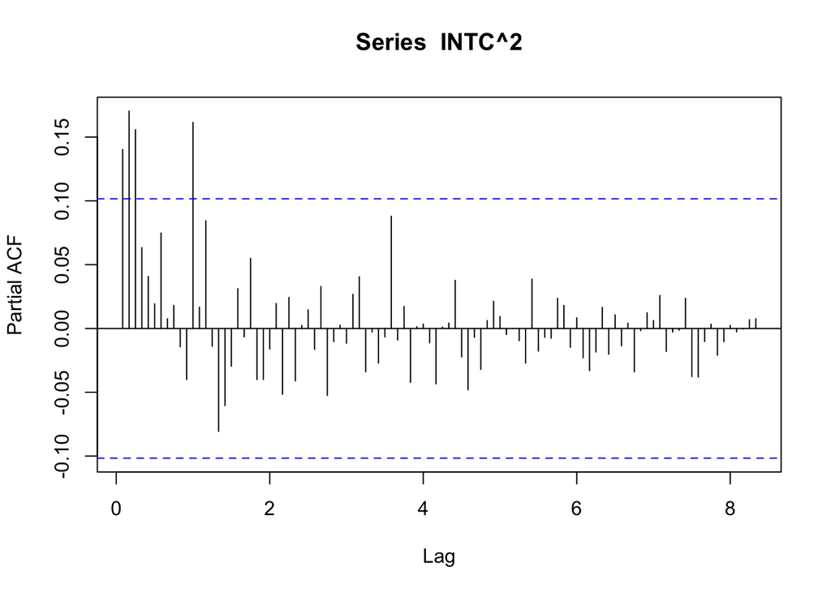

```r
pacf(INTC^2,lag=100)
```

```r
Box.test(INTC^2,3)
```

```
##
##  Box-Pierce test
##
## data:  INTC^2
## X-squared = 34.233, df = 3, p-value = 1.769e-07
```

En effet, si une série est un bruit blanc, alors la série élevée au carré doit l’être aussi, et ce n’est ici manifestement pas la cas en vertu du test de Box-Pierce. On tente de modéliser INTC^2 avec un ARMA :

```r
ARMA <- auto.arima(INTC^2,stationary=TRUE, seasonal=FALSE)
ARMA
```

```
## Series: INTC^2
## ARIMA(1,0,2) with non-zero mean
##
## Coefficients:
##          ar1      ma1     ma2    mean
##       0.8746  -0.8027  0.0725  0.0181
## s.e.  0.0758   0.0903  0.0610  0.0041
##
## sigma^2 estimated as 0.001384:  log likelihood=698.47
## AIC=-1386.95   AICc=-1386.78   BIC=-1367.35
```

```r
Box.test.2(residuals(ARMA),1:50)
```

```
##       Retard   p-value
##  [1,]      1 0.9974349
##  [2,]      2 0.9999866
##  [3,]      3 0.9302030
##  [4,]      4 0.9617276
##  [5,]      5 0.9784405
##  [6,]      6 0.9841967
##  [7,]      7 0.9807108
##  [8,]      8 0.9886544
##  [9,]      9 0.9950860
## [10,]     10 0.9929692
## [11,]     11 0.9685373
## [12,]     12 0.4814540
## [13,]     13 0.5566356
## [14,]     14 0.3151310
```

[output cut: 36 more lines]

Une modélisation ARMA(1,2) semble raisonnable. Cependant, si INTC était un GARCH(p,q) et, supposant que la série à un moment d’ordre 4, INTC^2 serait un ARMA(max(p,q),q), qui ne contient pas la classe ARMA(1,2). Cepedant, on voit que parmi les coeffcients :

```r
coef(ARMA)
```

```
##         ar1         ma1         ma2   intercept
##  0.87457353 -0.80266059  0.07251611  0.01809983
```

le coefficient ma2 est negligeable devant ar1 et ma1. On peut tenter de négliger ce coefficient et modéliser avec un ARMA(1,1) :

```r
arima(INTC^2,order=c(1,0,1))
```

```
##
## Call:
## arima(x = INTC^2, order = c(1, 0, 1))
##
## Coefficients:
##          ar1      ma1  intercept
##       0.9122  -0.7971     0.0182
## s.e.  0.0469   0.0685     0.0044
##
## sigma^2 estimated as 0.001374:  log likelihood = 697.75,  aic = -1387.5
```

```r
Box.test.2(residuals(arima(INTC^2,order=c(1,0,1))),1:50)
```

```
##       Retard   p-value
##  [1,]      1 0.4062199
##  [2,]      2 0.5891072
##  [3,]      3 0.5198242
##  [4,]      4 0.6824185
##  [5,]      5 0.8014312
##  [6,]      6 0.8586763
##  [7,]      7 0.8770328
##  [8,]      8 0.9094476
##  [9,]      9 0.9472803
## [10,]     10 0.9523248
## [11,]     11 0.8707045
## [12,]     12 0.3483931
## [13,]     13 0.4247163
## [14,]     14 0.2560471
```

[output cut: 36 more lines]

Cette modélisation est pertinente.

On entrevoit ainsi la possibilité que INTC provienne d’un GARCH(1,1).

L’analyse suivante nous montre que c’est une hypothèse raisonnable :

```r
Fit <- garch(INTC,order=c(1,1))
```

[output not shown]

```r
coef(Fit)
```

```
##          a0          a1          b1
## 0.001158365 0.087395034 0.845653382
```

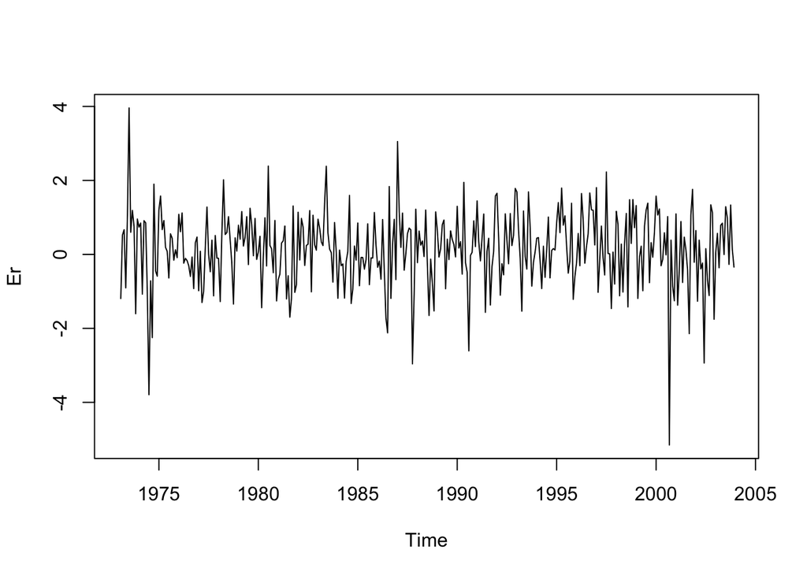

```
##        Retard   p-value
##   [1,]      1 0.7192460
##   [2,]      2 0.8464215
##   [3,]      3 0.5421388
##   [4,]      4 0.4955916
##   [5,]      5 0.6374841
##   [6,]      6 0.6352119
##   [7,]      7 0.3365955
##   [8,]      8 0.3140770
##   [9,]      9 0.4056276
##  [10,]     10 0.4827762
##  [11,]     11 0.5419189
##  [12,]     12 0.5709801
##  [13,]     13 0.5042275
##  [14,]     14 0.3256200
```

[output cut: 86 more lines]

```r
Er <- residuals(Fit)
plot.ts(Er) ; Box.test.2(Er,1:100)
```

On peut alors tenter de prédire la volatilité $\sigma_t^2$ de la série INTC $X_t=\sigma_t\varepsilon_t$ à l’aide des formules du cours. En effet, on a pour un GARCH(1,1) :

$$X_t=\sigma_t\varepsilon_t,\qquad \sigma_t^2=\omega+ \alpha X_{t-1}^2+\beta\sigma_{t-1}^2.$$

On nommes les constantes :

```r
omega = coef(Fit)[1]
alpha = coef(Fit)[2]
beta = coef(Fit)[3]
n = length(INTC) ; n
```

```
## [1] 372
```

On commence par estimer $\sigma_n^2$ par récurrence (en supposant que $\sigma_0=0$) :

```r
sigma2 <- vector()
sigma2[1]=0
for (i in 1:n){sigma2[i+1]= omega +alpha*INTC[i]^2 + beta*sigma2[i]}
sigma2_n=sigma2[n+1]
```

Ensuite, on crée une fonction $\verb'sigma2_est'$ de $\ell$ qui nous renvoie $\hat\sigma_n^2(\ell)$ comme suite :

```r
sigma2_est <- function(l){
  sig_est1 <- unname(omega + alpha*INTC[n]^2 + beta*sigma2_n)
  if (l==1){return(sig_est1)}
  else {
    Est <- vector()
    Est[1]=sig_est1
    for (i in 2:l){Est[i]=omega*(1-(alpha+beta)^l)/(1-alpha-beta)+(alpha+beta)^l*Est[i-1]}
    return(Est[l])
    }
}
```

Par exemple, on prédit à l’horizon $\ell=1,2,3,4$ :

```r
sigma2_est(1) ; sigma2_est(2) ; sigma2_est(3) ; sigma2_est(4)
```

```
## [1] 0.01503668
```

```
## [1] 0.0153298
```

```
## [1] 0.01580714
```

```
## [1] 0.0163155
```